# 記憶研究的演進

2020-11-08

## 單元說明

- 開場：自由回憶的回溯促進
- 概述[可重製的記憶研究](https://scgeeker.github.io/EXPPSY_Opensci/memory.html)
- 記憶研究主題的演進
- 記憶研究方法的改良

## Deryl Bem: 自由回憶的回溯促進

[figure not shown]

- [Feeling the future](https://www.researchgate.net/publication/49798137_Feeling_the_Future_Experimental_Evidence_for_Anomalous_Retroactive_Influences_on_Cognition_and_Affect)

**參與者內設計的短期記憶實驗**  
**實驗程序**  
1. 指導語 \(\rightarrow\) 2項刺激搜尋能力調查 \(\rightarrow\) 3分鐘休息  
2. 瀏覽48項實驗刺激(24P,24C) \(\rightarrow\) 意外自由回憶  
3. 24項P刺激歸類作業

**實驗結果**  
\(DR \% = \frac{[(P - C) \times (P + C)]}{576}\)  
EXP 8: \(DR \% = 2.27 \%, t(99) = 1.92, p = .029,\)  
\(d = 0.19\)  
EXP 9: \(DR \% = 4.21 \%, t(49) = 2.96, p = .002,\)  
\(d = 0.42\)

## 赫曼．艾賓浩斯(1850-1909)

[figure not shown]

- 實驗者自己就是受試者
- 採用隨機分派方法，測量學習無意義音節(kyh,pil,goj)的進展
- 數百套無意義音節隨機組合，分派至不同實驗日期學習或測試
- 依變項：正確覆誦的比率與經過的天數

## 學習曲線

[figure not shown]

學習曲線紀錄範例

## 間隔重覆

[figure not shown]

遺忘曲線示意圖。取自維基百科。

## 短期記憶資訊容量: Miller (1956)

- limit of channel capacity for unidimensional stimuli
  - 2 ~ 4 **bits**
- limit of channel capacity for multidimensional stimuli
  - Magic number 7

## 短期記憶資訊壓縮: memory span

- 1 bit contained how many items
  - binary digits
  - decimal digits
  - letters
  - words

## 現代版短期記憶實驗範例

- 取自psytoolkit實驗資源庫，使用滑鼠或平板進行
- [順向再認作業](https://www.psytoolkit.org/library/experiment_corsi.html) ~ [說明網頁](https://www.psytoolkit.org/library/corsi.html)
- [逆向再認作業](https://www.psytoolkit.org/library/experiment_backward_corsi.html) ~ [說明網頁](https://www.psytoolkit.org/library/backward_corsi.html)

## 記憶系統與歷程

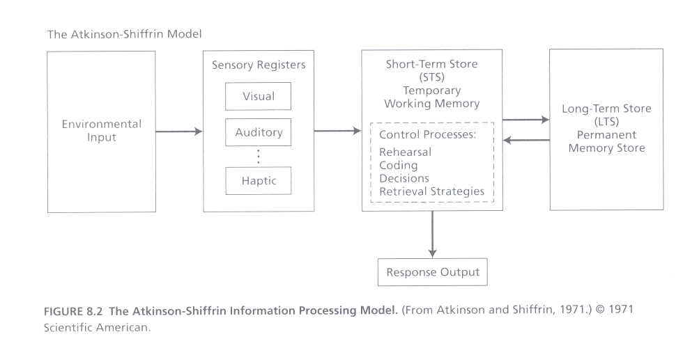

Atkinson 與 Shiffrin(1968)提出的記憶系統模型。

## 感覺記憶登錄

[figure not shown]

Sperling部分報告實驗程序。取自維基百科。

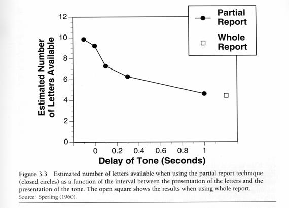

Sperling部分報告實驗結果。

**能被重製的記憶實驗**

## 序列位置效應

Murdock (1962)

[示範程序](https://www.psytoolkit.org/cgi-bin/psy2.6.1/survey?s=AGONz)(請開擴音或戴耳機); [問卷腳本](https://osf.io/87zpm/)

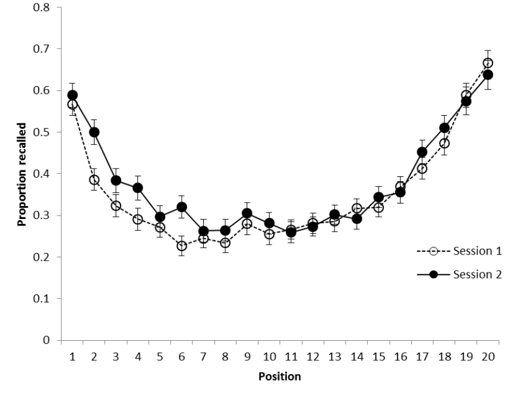

典型列表學習實驗的序列位置曲線。取自Zwaan et al.(2017)附錄。

## 間隔效應

Greene (1989)

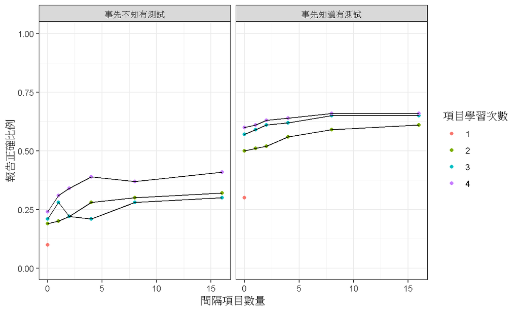

重製Greene(1989)之實驗1結果曲線圖。

## DRM記憶錯覺實驗範例

[體驗實驗](https://www.psytoolkit.org/cgi-bin/psy2.6.1/survey?s=aD3Kz) (請開擴音或戴耳機)

## DRM記憶錯覺實驗

Roediger and McDermott (1995)

| 測試項目 | 列表安排 | 項目數目 | (R)再認且確認學過(%) | (K)再認有印象(%) | 總再認率(%) |
| --- | --- | --- | --- | --- | --- |
|  | **學習後回憶** | 24 | 57 | 22 | 79 |
| 列表內字詞 | 學習後算術 | 24 | 41 | 24 | 65 |
|  | 未學習 | 24 | 2 | 9 | 11 |
|  | **學習後回憶** | 8 | 58 | 23 | 81 |
| 列表關鍵詞 | 學習後算術 | 8 | 38 | 34 | 72 |
|  | 未學習 | 8 | 3 | 13 | 16 |

## 真的有自由回憶的回溯促進嗎？

[Failing the Future](http://dx.plos.org/10.1371/journal.pone.0033423)

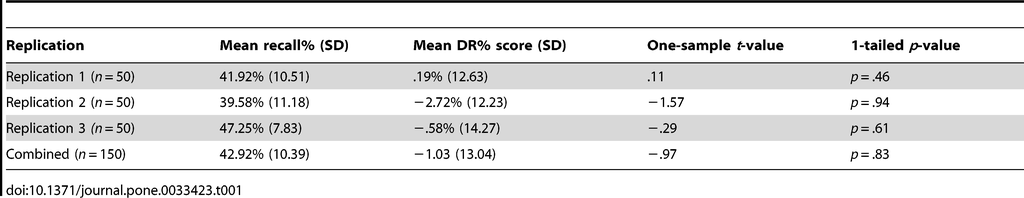

Ritchie, Wiseman, 與French (2012)的重製實驗結果。

## 參考文獻

Greene, Robert L. 1989. “Spacing Effects in Memory: Evidence for a Two-Process Account.” *Journal of Experimental Psychology: Learning, Memory, and Cognition* 15 (3): 371–77. https://doi.org/10.1037/0278-7393.15.3.371.

Miller, George A. 1956. “The Magical Number Seven, Plus or Minus Two: Some Limits on Our Capacity for Processing Information.” *Psychological Review* 63 (2): 81–97. https://doi.org/10.1037/h0043158.

Murdock, Bennet B., Jr. 1962. “The Serial Position Effect of Free Recall.” *Journal of Experimental Psychology* 64 (5): 482–88. https://doi.org/10.1037/h0045106.

Roediger, Henry L., and Kathleen B. McDermott. 1995. “Creating False Memories: Remembering Words Not Presented in Lists.” *Journal of Experimental Psychology: Learning, Memory, and Cognition* 21: 803–14. https://doi.org/10.1037/0278-7393.21.4.803.